# HW 10

Brenda Onyango

10/30/2021

## Exercise 9.1

1. A normal prior is reasonable for B0 and B1 because these can take values around a center value (positive and negative or even zero).
2. A normal prior isn’t reasonable for $\sigma$ because sigma can’t be negative.
3. The difference between weakly informative priors and vague priors is that weakly informative priors are more focused in that they reflect uncertainty  
   across a range of *sensible* parameter values, whereas vague priors put weight on non-sensible parameter values. With weakly informative priors, chains don’t have to spend time exploring non-sensible parameter values.

## Exercise 9.2

Predictor = X and response variable = Y

1. X = arm length, Y = height
2. X = distance b/w home and work, Y = person’s carbon footprint
3. X = age, Y = child’s vocabulary level
4. X = person’s sleep habits, Y = reaction time

Notice these have an order i.e. a person’s carbon footprint can’t happen before they commute.

## Exercise 9.3

Y = B0 + B1X where B0 is y-intercept (what typical Y value is when and X = 0) and B1 is slope. X indicates predictor.

1. Y_kangheight = B_0 + X_ageB_1 Here B_0 is the height of the kangaroo at 0 months old or when it’s born and B_1 is how much the kangaroo grows for each increase in month. B_1 is positive.
2. Y_Githubfollowers = B_0 + X_commitsB_1 Here B_0 is the number of followers when the data scientists has 0 Github commits and B_1 is how many followers are added for each increase in Github commits. Assuming B_1 is positive.
3. Y_visitors = B_0 + X_rainfallB_1 B_0 is the number of visitors to a local park when there are 0 inches of rainfall. B_1 is the decrease in visitors for each additional inches of rainfall. B_1 is negative.
4. Y_netflix = B_0 + X_sleepB_1 B_0 is the daily hours of Netflix a person watches when they have 0 hours of sleep. B_1 is the decrease in netflix hours for each increase in the hours of sleep. B_1 is negative.

## Exercise 9.4

$\sigma$ tells us about the spread of data in our sample. More spread or a higher standard deviation means that the relationship between X and Y is weaker. Less spread or lower variation means the relationship between X and Y is stronger.

```r
# Load packages
library(bayesrules)
library(tidyverse)
library(rstan)
library(rstanarm)
```

```r
library(bayesplot)
library(tidybayes)
library(janitor)
library(broom.mixed)
```

## Exercise 9.5

1. X = predictor = person’s age in years, Y = orange juice consumption in gallons

b&c) data: $Y_{i}$|$B_O$,$B_1$, $\sigma$ ~ N($u_i$, $\sigma$^2) with $u_i$ = $B_O$ + $B_1$$X_i$

B0 ~ N(m0, s^2)

B1 ~ N(m1, s1^2)

$\sigma$ ~ Exp(l)

4. The unknown parameters are BO, B1, and $\sigma$. B1 can be 0 if we include infants under the age of 1 but a more realistic value is between 1-78 years of age with an average of 38 and sd of 13 years; B0 has to be positive (can’t drink negative amount of orange juice). $\sigma$ has to be positive.
5. Let’s assume that the capacity to drink OJ increases as we increase in age because of growing stomach capacity. Drinking OJ could have a normal distribution where younger and older people drink less than middle aged people.

Let’s say that the average amount of gallons is 20 (around 320 cups a year). let’s say the amount of orange juice people drink per year has standard deviation of 2 gallons.

For the age assumptions I used average age, life expectancy, and sd from google searches. For the orange juice priors I based on my personal habits of drinking between 0.5-1.5 cups of OJ in a day and multiplied by 365 to get around 20 gallons a year.

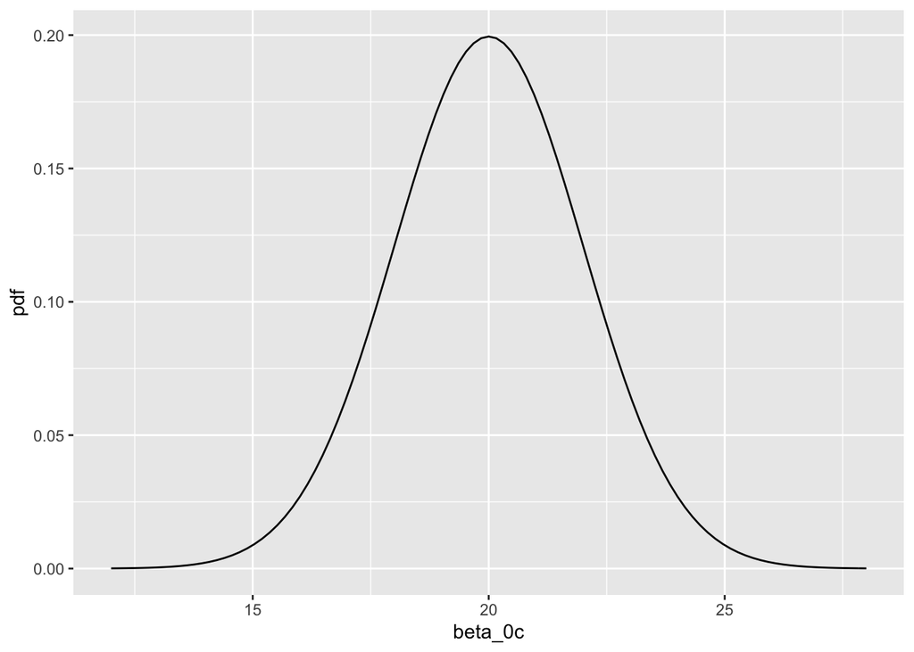

```r
plot_normal(mean = 20, sd = 2) + #average of .05 gallons of oj for B1
  labs(x = "beta_0c", y = "pdf")
```

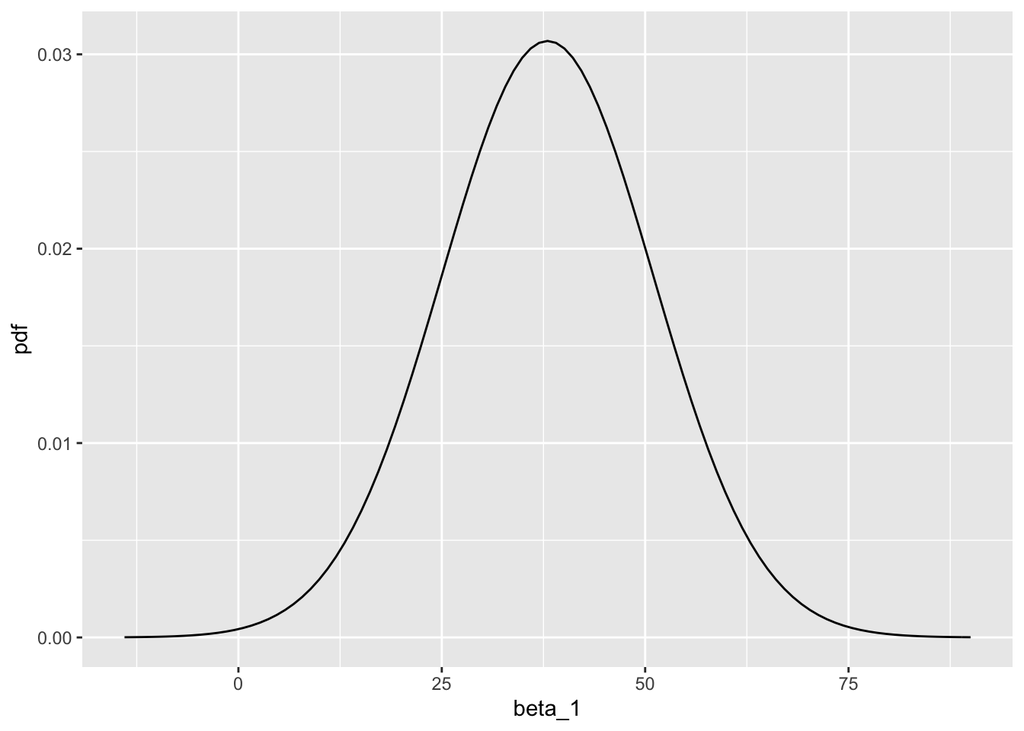

```r
plot_normal(mean = 38, sd = 13) + #average age and sd of 13 years
  labs(x = "beta_1", y = "pdf")
```

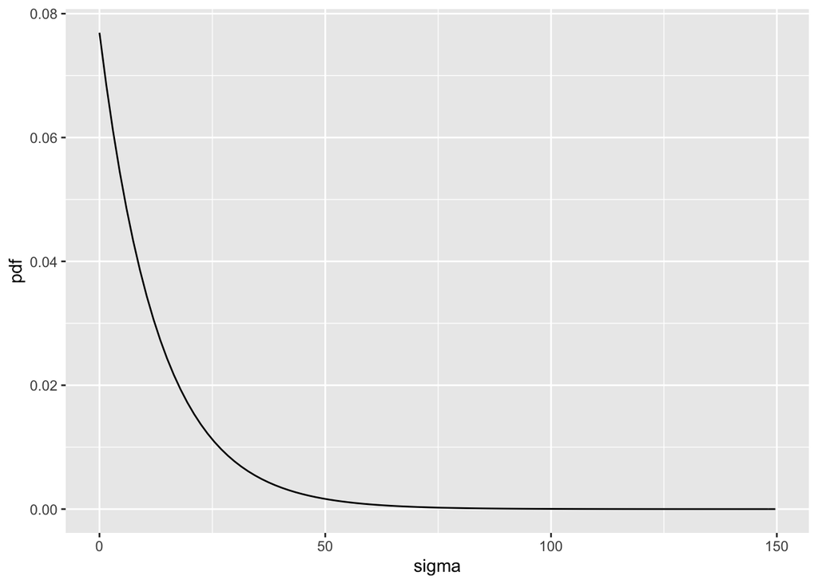

```r
plot_gamma(shape = 1, rate = 0.07692307692) + #exponential model of sd 1/13 gives l of 0.07692307692
  labs(x = "sigma", y = "pdf")
```

Plugging in the tuned priors we can specificy the Bayesian regression model like this: $Y_{i}$|$B_O$,$B_1$, $\sigma$ ~ N($u_i$, $\sigma$^2) with $u_i$ = $B_O$ + $B_1$$X_i$

B0 ~ N(20, 4)

B1 ~ N(38, 169)

$\sigma$ ~ Exp(0.0769)

# Exercise 9.6

1. X = predictor = today’s high temperature, Y = tomorrow’s high temperature.

b &c) data: $Y_{i}$|$B_O$,$B_1$, $\sigma$ ~ N($u_i$, $\sigma$^2) with $u_i$ = $B_O$ + $B_1$$X_i$

B0 ~ N(m0, s^2)

B1 ~ N(m1, s1^2)

$\sigma$ ~ Exp(l)

4. TThe unknown parameters are BO, B1, and $\sigma$. B1 can between 0 and 56 degrees celcius (highest temp ever recorded was 134). B0 has to be positive and also in the same range as B1 since they’re both temperatures. $\sigma$ has to be positive.
5. I’ll assume it’s fall so the average of today’s temperature and tomorrow’s is 15 degrees Celsius. I’ll assume a sdev of 3 degrees Celsius. I’ll use these values to build a model.

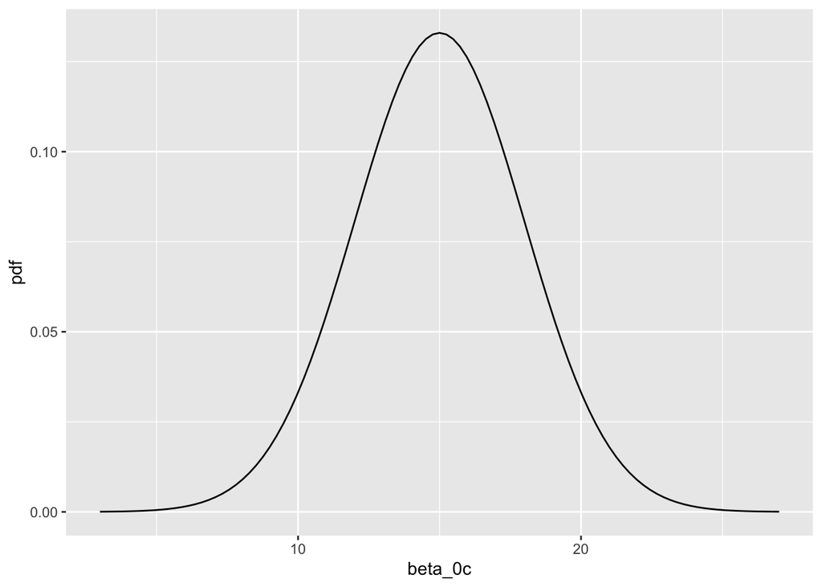

```r
plot_normal(mean = 15, sd = 3) + #average of 15 degrees for B1
  labs(x = "beta_0c", y = "pdf")
```

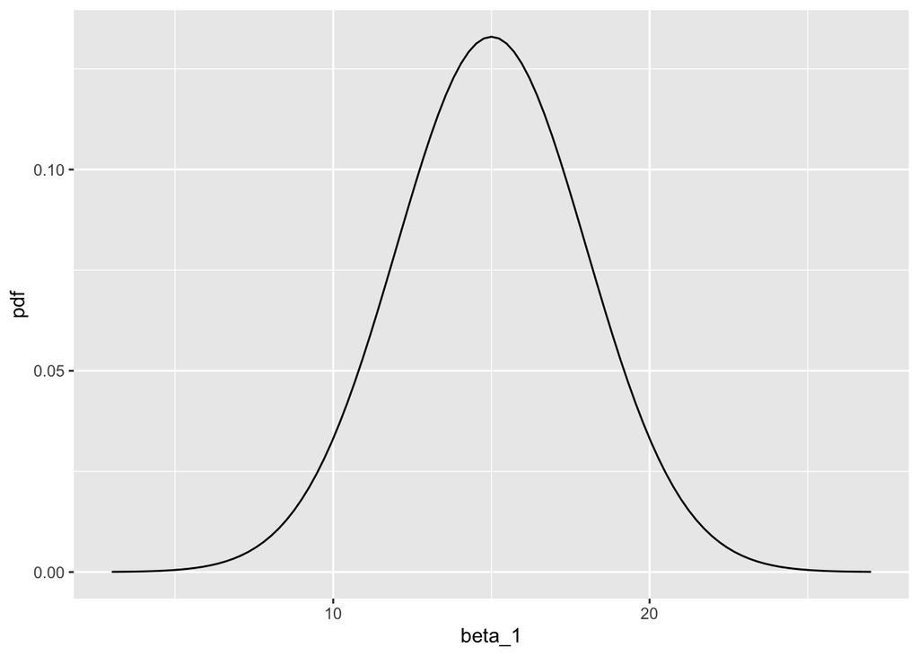

```r
plot_normal(mean = 15, sd = 3) + #average temp and sd of 3 degrees celsius
  labs(x = "beta_1", y = "pdf")
```

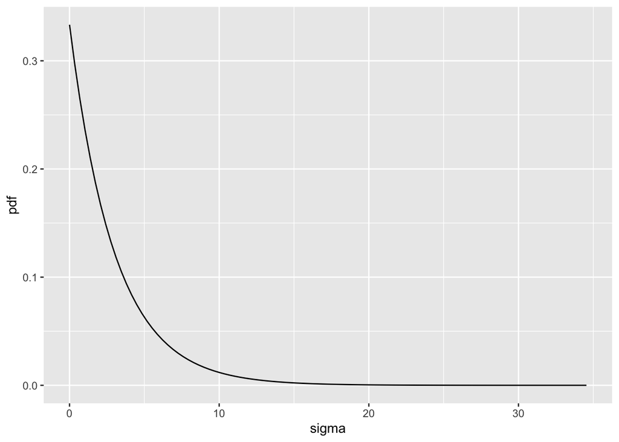

```r
plot_gamma(shape = 1, rate = 0.333333) + #exponential model of sd 1/3 gives l of 0.333
  labs(x = "sigma", y = "pdf")
```

My tuned model is now: data: $Y_{i}$|$B_O$,$B_1$, $\sigma$ ~ N($u_i$, $\sigma$^2) with $u_i$ = $B_O$ + $B_1$$X_i$

B0 ~ N(15, 9)

B1 ~ N(15, 9)

$\sigma$ ~ Exp(0.333)

# Exercise 9.7

1. False; MCMC is used to *approximate* the posterior.
2. True.

# Exercise 9.8